# Data Entry Performance on Clinical Trials

rbtik

16/12/2014

## Problem statement and hypothesis to be tested

Timely data entry on the clinical database is crucial for the business of any pharmaceutical or medical device company in order to bring innovative products to the market. Clean data needs to be used to support stepwise reporting and approval of your new drug or medical device. Any delay on getting these, has huge business consequences such as losing your competitive advantage or not being able to provide this product to the general population (indicated with the condition which the drug or device cures).

Most investigational clinical trials have limited amount of patients and sites (i.e. hospitals) in which health authorities have approved them to conduct their trials so itâs important that these sites are engaged and provide timely and complete data entry to the sponsoring company. More importantly, all of them need to be entering accurate data at the same pace so the different study milestones for the study (e.g. procedure, 30 days after procedureâ¦) are available short after these had been completed.

Moreover, these clinical trials are most of the times international so they involve sites from different countries. Clinical practices vary across countries: for example while in Germany most sites will have in-hospital facilities for Echocardiography, in other countries as Spain, these might be off-hospital so the delay in producing the results can be delayed.

Finally, in-hospital resource allocation is crucial in order to facilitate data entry as this data can only be entered by the principal investigator (i.e. head unit physician) or the research nurse (i.e. most of the times, head nurse of the unit). These resources are many times over allocated participating in several studies from several sponsor companies so the availability of these can play an important role on the data entry performance for the investigational site.

For this prediction of Number of Days (dependent variable) from other independent variables (i.e. Site, Form, User), our hypothesis will assume that there are differences across sites in terms of data entry performance. We will detail later which ones these might be.

Consider the dataset available in the file “SiteDataEntry.csv”. The file contains the following columns:

**Variable Description**

*AuditID* NUMERIC: Unique ID of this audit entry.

*SiteId* NUMERIC: Unique ID for the Site.

*SubjectId* NUMERIC: Unique ID for the Subject (patient).

*SubjectName* STRING: Composite of Study, Site and Subject in text form.

*FolderId* NUMERIC: Unique ID for the Visit.

*FolderName* STRING: Name of the visit (i.e. Screening, Baseline, Dischargeâ¦).

*FormId* NUMERIC: Unique ID for the Assessment.

*FormName* STRING: Name of the assessment (i.e. Vital Signs, ECHO, CT Scanâ¦).

*FieldId* NUMERIC: Unique ID for the datapoint.

*FieldName* STRING: Coded name of the datapoint (i.e. systolic blood preassure, #Echo date, weightâ¦).

*Log#* NUMERIC: Sequence number for datapoints that appear more than once on a given assessment (form).

*RecordID* NUMERIC: ID for the entry. 2 records in the Audit Trial table with the same Record ID refer to the same record (i.e. first entry, further modifications of the same record).

*AuditAction* TEXT: Description of the action performed (e.g. âUser entered ‘14 Jan 2013’ reason for change: Data Entry Revisionâ).

*UserID* NUMERIC: Unique ID of the user performing the action.

*RoleId* NUMERIC: Unique ID of the userâs role (e.g. 25 for Research Coordinator).

*RoleName* CATEGORICAL: Description of the role.

*AuditActionType* CATEGORICAL: Description of action type (e.g. Entered, EnteredWithChangeCodeâ¦).

*AuditTime* DATETIME: When action was performed (format MM/DD/YYYY HH:mm).

*Days* NUMERIC: Calculation for number of days between when the assessment happened and the date site entered data (âAuditTimeâ - âAssessmentDateâ).

Reading the data from the file and store it into a dataframe

```r
inp <- read.csv("SiteDataEntry.csv")
str(inp)  # get some info about the structure of the dataset
```

```
## 'data.frame':    7791 obs. of  23 variables:
##  $ AuditID        : int  81971975 82051895 82159679 82159806 82166626 82166541 82166542 82166554 82166566 82166578 ...
##  $ StudyID        : int  84 84 84 84 84 84 84 84 84 84 ...
##  $ SiteId         : int  232 232 232 232 232 232 232 232 232 232 ...
##  $ Country        : Factor w/ 4 levels "DE","FR","IT",..: 1 1 1 1 1 1 1 1 1 1 ...
##  $ SubjectId      : int  35603 35652 35652 35708 35603 35603 35603 35603 35603 35603 ...
##  $ SubjectName    : Factor w/ 146 levels "SF SP3 0553 001",..: 47 48 48 49 47 47 47 47 47 47 ...
##  $ FolderId       : int  54212 54212 54212 54212 54198 54198 54198 54198 54198 54198 ...
##  $ FolderName     : Factor w/ 7 levels "30 Day (1)","Baseline (1)",..: 6 6 6 6 2 2 2 2 2 2 ...
##  $ FormId         : int  267654 267654 267654 267654 267635 267635 267635 267635 267635 267635 ...
##  $ FormName       : Factor w/ 16 levels "30 Day and 1 Year Follow-up Assessments",..: 10 10 10 10 8 8 8 8 8 8 ...
##  $ FieldId        : int  5268901 5268901 5268901 5268901 5268442 5268442 5268442 5268442 5268442 5268442 ...
##  $ FieldName      : Factor w/ 16 levels "ADMITDAT","CTSDAT",..: 9 9 9 9 6 6 6 6 6 6 ...
##  $ Log.           : int  0 0 0 0 8 0 1 2 3 4 ...
##  $ RecordID       : int  5597591 5606354 5606354 5617654 5617781 5617773 5617774 5617775 5617776 5617777 ...
##  $ AuditAction    : Factor w/ 486 levels " User entered '01 Apr 2013' ",..: 19 19 196 195 4 4 4 4 4 4 ...
##  $ AssessmentDate : Factor w/ 319 levels "01 Apr 2013",..: 13 13 130 130 3 3 3 3 3 3 ...
##  $ AssDate        : int  41276 41276 41288 41288 41275 41275 41275 41275 41275 41275 ...
##  $ UserID         : int  1351 1354 1351 1351 1351 1351 1351 1351 1351 1351 ...
##  $ RoleId         : int  25 25 25 25 25 25 25 25 25 25 ...
##  $ RoleName       : Factor w/ 1 level "Research Coordinator": 1 1 1 1 1 1 1 1 1 1 ...
##  $ AuditActionType: Factor w/ 2 levels "Entered","EnteredWithChangeCode": 1 1 2 1 1 1 1 1 1 1 ...
##  $ AuditTime      : num  41286 41289 41290 41290 41291 ...
##  $ Days           : int  9 12 2 2 15 15 15 15 15 15 ...
```

```r
attach(inp)
```

## Data Exploration

Lets explore some independent variables to assess dependency. First we look at *FormId* (colored by *SiteId*)

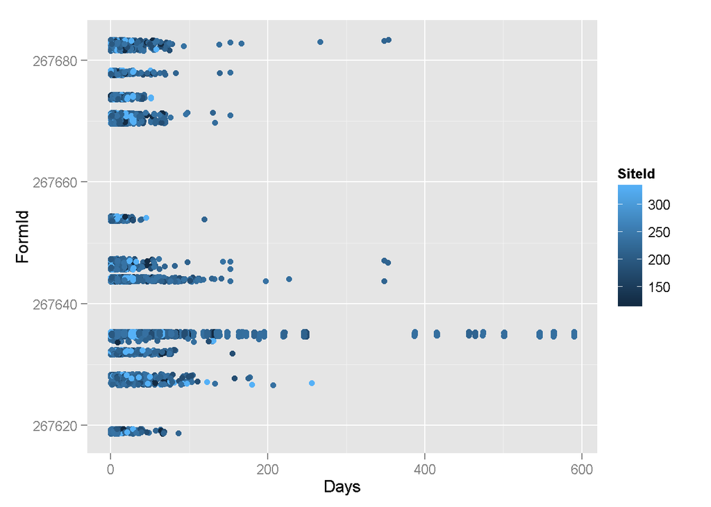

```r
library(ggplot2)
qplot(Days,FormId,data=inp,geom="jitter",colour=SiteId)
```

Above plot tell us that most of the higher Days are related to a SiteId so lets look deeper at a *FieldId*

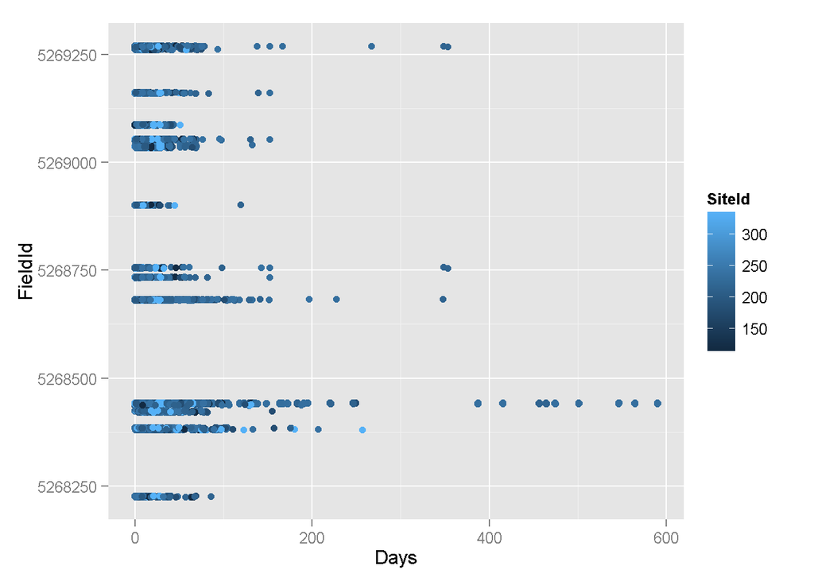

```r
qplot(Days,FieldId,data=inp,geom="jitter",colour=SiteId)
```

Again at a Field level some of the highest points belong from same *SiteId* so we will try this variable first

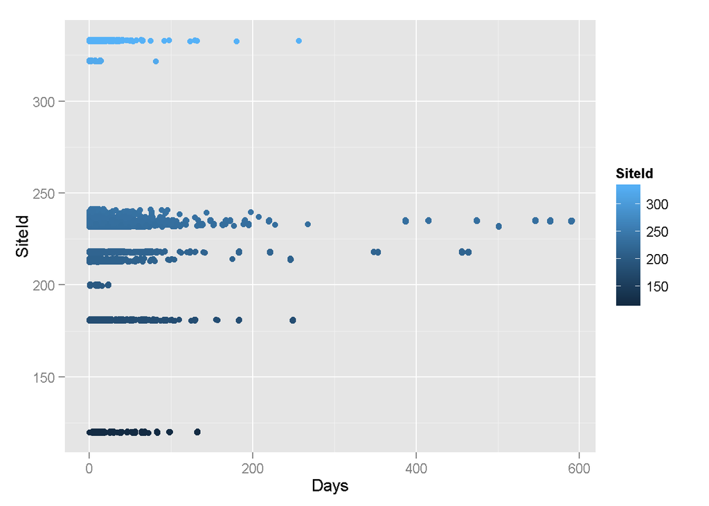

```r
qplot(Days,SiteId,data=inp,geom="jitter",colour=SiteId)
```

```
## stat_bin: binwidth defaulted to range/30. Use 'binwidth = x' to adjust this.
```

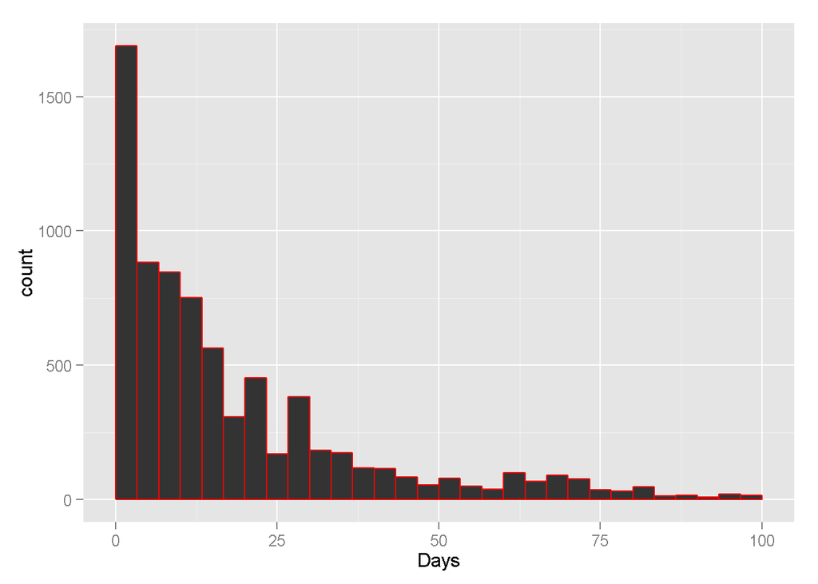

```r
qplot(Days,data=inp, geom="histogram", xlim=c(0,100), binwith=0.5, colour=I("red"))
```

From above we can see most of the entries resume in less than 25 days. Lets check correlations between variables (subset of numerical ones)

```r
library(Hmisc)
ninp <- data.frame(inp$SiteId, inp$SubjectId, inp$FormId, inp$FieldId, inp$AssDate, inp$UserID, inp$Days)
rcorr(as.matrix(ninp))
```

```
##               inp.SiteId inp.SubjectId inp.FormId inp.FieldId inp.AssDate
## inp.SiteId          1.00          0.02       0.00        0.00        0.06
## inp.SubjectId       0.02          1.00      -0.01       -0.01        0.84
## inp.FormId          0.00         -0.01       1.00        0.99        0.02
## inp.FieldId         0.00         -0.01       0.99        1.00        0.02
## inp.AssDate         0.06          0.84       0.02        0.02        1.00
## inp.UserID          0.72          0.09       0.00        0.00        0.17
## inp.Days           -0.05          0.03      -0.14       -0.15       -0.15
##               inp.UserID inp.Days
## inp.SiteId          0.72    -0.05
## inp.SubjectId       0.09     0.03
## inp.FormId          0.00    -0.14
## inp.FieldId         0.00    -0.15
## inp.AssDate         0.17    -0.15
## inp.UserID          1.00    -0.01
## inp.Days           -0.01     1.00
##
## n= 7791
##
##
## P
##               inp.SiteId inp.SubjectId inp.FormId inp.FieldId inp.AssDate
## inp.SiteId               0.1439        0.8796     0.9070      0.0000
## inp.SubjectId 0.1439                   0.5306     0.5541      0.0000
## inp.FormId    0.8796     0.5306                   0.0000      0.0463
## inp.FieldId   0.9070     0.5541        0.0000                 0.0344
## inp.AssDate   0.0000     0.0000        0.0463     0.0344
## inp.UserID    0.0000     0.0000        0.8461     0.8962      0.0000
## inp.Days      0.0000     0.0107        0.0000     0.0000      0.0000
##               inp.UserID inp.Days
## inp.SiteId    0.0000     0.0000
## inp.SubjectId 0.0000     0.0107
## inp.FormId    0.8461     0.0000
## inp.FieldId   0.8962     0.0000
## inp.AssDate   0.0000     0.0000
## inp.UserID               0.3652
## inp.Days      0.3652
```

## Model diagnostics

Lets try some independent variables and decide our best predictors. We will categorise *SiteId* as we have seen some sites predict better than others and have their own conditions.

```r
inp$SiteId.f <- factor(inp$SiteId)
fit1 <- lm(Days ~ SiteId.f, data=inp)
summary(fit1)
```

```
##
## Call:
## lm(formula = Days ~ SiteId.f, data = inp)
##
## Residuals:
##    Min     1Q Median     3Q    Max
## -54.94 -18.39 -11.00   5.35 535.06
##
## Coefficients:
##             Estimate Std. Error t value Pr(>|t|)
## (Intercept)   29.958      2.969  10.091  < 2e-16 ***
## SiteId.f181    2.693      3.607   0.747 0.455284
## SiteId.f200  -20.329      8.230  -2.470 0.013528 *
## SiteId.f213  -16.424      4.042  -4.064 4.88e-05 ***
## SiteId.f214   -7.608      3.771  -2.017 0.043702 *
## SiteId.f218   16.638      3.622   4.594 4.42e-06 ***
## SiteId.f232  -12.381      3.376  -3.667 0.000247 ***
## SiteId.f233   -9.171      3.433  -2.671 0.007575 **
## SiteId.f234  -11.194      4.452  -2.514 0.011951 *
## SiteId.f235   24.980      3.476   7.187 7.23e-13 ***
## SiteId.f237  -11.566      4.037  -2.865 0.004185 **
## SiteId.f239   -9.404      5.803  -1.621 0.105138
## SiteId.f240  -14.941      6.080  -2.457 0.014021 *
## SiteId.f241  -19.151      6.165  -3.107 0.001899 **
## SiteId.f322  -24.033      8.230  -2.920 0.003509 **
## SiteId.f333  -11.963      3.940  -3.036 0.002405 **
## ---
## Signif. codes:  0 '***' 0.001 '**' 0.01 '*' 0.05 '.' 0.1 ' ' 1
##
## Residual standard error: 56.41 on 7775 degrees of freedom
## Multiple R-squared:  0.05679,    Adjusted R-squared:  0.05497
## F-statistic: 31.21 on 15 and 7775 DF,  p-value: < 2.2e-16
```

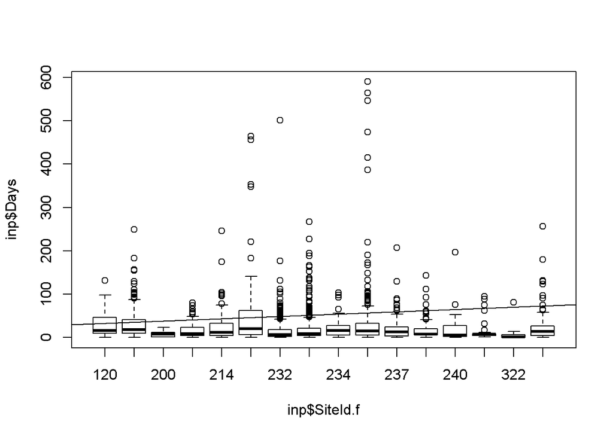

```r
plot(inp$Days ~ inp$SiteId.f)
abline(fit1)
```

The same happens for *FormId*. As we have seen in the correlations, going to the field level doesn’t seem to add value out of the Form so we will use only Form.

```r
inp$FormId.f <- factor(inp$FormId)
fit2 <- lm(Days ~ FormId.f, data=inp)
summary(fit2)
```

```
##
## Call:
## lm(formula = Days ~ FormId.f, data = inp)
##
## Residuals:
##    Min     1Q Median     3Q    Max
## -47.41 -24.19 -10.45   2.51 552.81
##
## Coefficients:
##                Estimate Std. Error t value Pr(>|t|)
## (Intercept)     17.0377     4.5228   3.767 0.000166 ***
## FormId.f267627  25.1821     6.5972   3.817 0.000136 ***
## FormId.f267628   8.9707     5.8413   1.536 0.124648
## FormId.f267632   3.4523     5.5944   0.617 0.537190
## FormId.f267634  30.3697    11.8708   2.558 0.010536 *
## FormId.f267635  20.1553     4.6148   4.368 1.27e-05 ***
## FormId.f267644   7.6671     5.0842   1.508 0.131592
## FormId.f267646  -5.7019     5.7332  -0.995 0.319993
## FormId.f267647  -2.4764     6.4373  -0.385 0.700469
## FormId.f267654  -8.9781     6.4803  -1.385 0.165957
## FormId.f267670  -2.5389     5.2950  -0.479 0.631603
## FormId.f267671  -4.7746     5.1999  -0.918 0.358544
## FormId.f267674  -5.5918     5.6075  -0.997 0.318695
## FormId.f267678  -4.1430     6.0015  -0.690 0.490006
## FormId.f267682   0.8512     6.3665   0.134 0.893649
## FormId.f267683   1.8640     5.6108   0.332 0.739739
## ---
## Signif. codes:  0 '***' 0.001 '**' 0.01 '*' 0.05 '.' 0.1 ' ' 1
##
## Residual standard error: 57.03 on 7775 degrees of freedom
## Multiple R-squared:  0.03579,    Adjusted R-squared:  0.03393
## F-statistic: 19.24 on 15 and 7775 DF,  p-value: < 2.2e-16
```

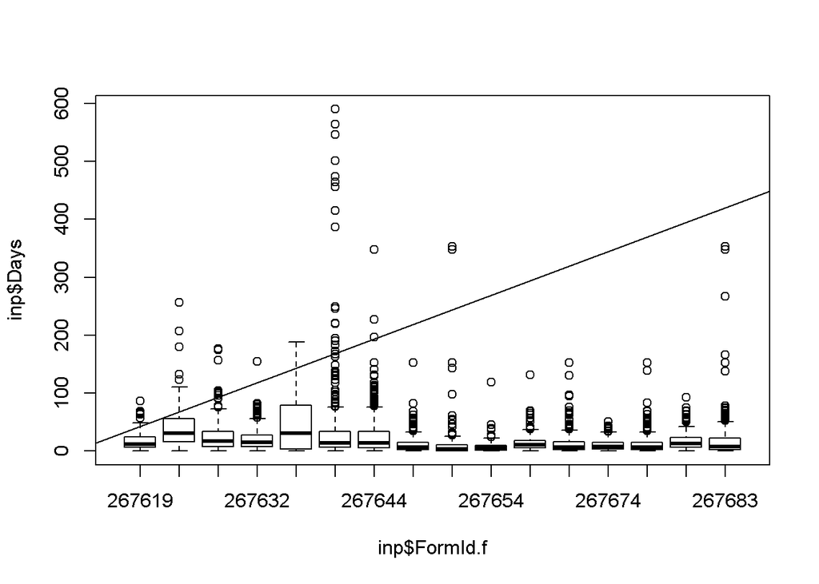

```r
plot(inp$Days ~ inp$FormId.f)
abline(fit2)
```

```r
fit3 <- lm(Days ~ SubjectId, data=inp)
summary(fit3)
```

```
##
## Call:
## lm(formula = Days ~ SubjectId, data = inp)
##
## Residuals:
##    Min     1Q Median     3Q    Max
## -30.06 -22.77 -15.59  -0.17 564.25
##
## Coefficients:
##              Estimate Std. Error t value Pr(>|t|)
## (Intercept) 7.1406658  8.0057924   0.892   0.3725
## SubjectId   0.0004610  0.0001805   2.554   0.0107 *
## ---
## Signif. codes:  0 '***' 0.001 '**' 0.01 '*' 0.05 '.' 0.1 ' ' 1
##
## Residual standard error: 58 on 7789 degrees of freedom
## Multiple R-squared:  0.0008367,  Adjusted R-squared:  0.0007084
## F-statistic: 6.523 on 1 and 7789 DF,  p-value: 0.01067
```

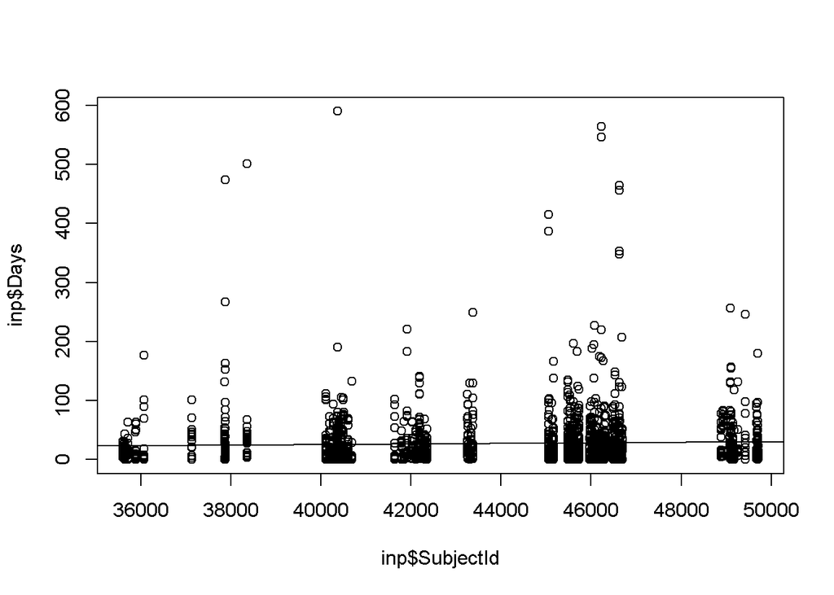

```r
plot(inp$Days ~ inp$SubjectId)
abline(fit3)
```

```r
fit4 <- lm(Days ~ UserID, data=inp)
summary(fit4)
```

```
##
## Call:
## lm(formula = Days ~ UserID, data = inp)
##
## Residuals:
##    Min     1Q Median     3Q    Max
## -29.46 -23.17 -15.51   0.84 562.42
##
## Coefficients:
##              Estimate Std. Error t value Pr(>|t|)
## (Intercept) 30.975874   3.874844   7.994 1.49e-15 ***
## UserID      -0.002413   0.002665  -0.906    0.365
## ---
## Signif. codes:  0 '***' 0.001 '**' 0.01 '*' 0.05 '.' 0.1 ' ' 1
##
## Residual standard error: 58.02 on 7789 degrees of freedom
## Multiple R-squared:  0.0001053,  Adjusted R-squared:  -2.311e-05
## F-statistic:  0.82 on 1 and 7789 DF,  p-value: 0.3652
```

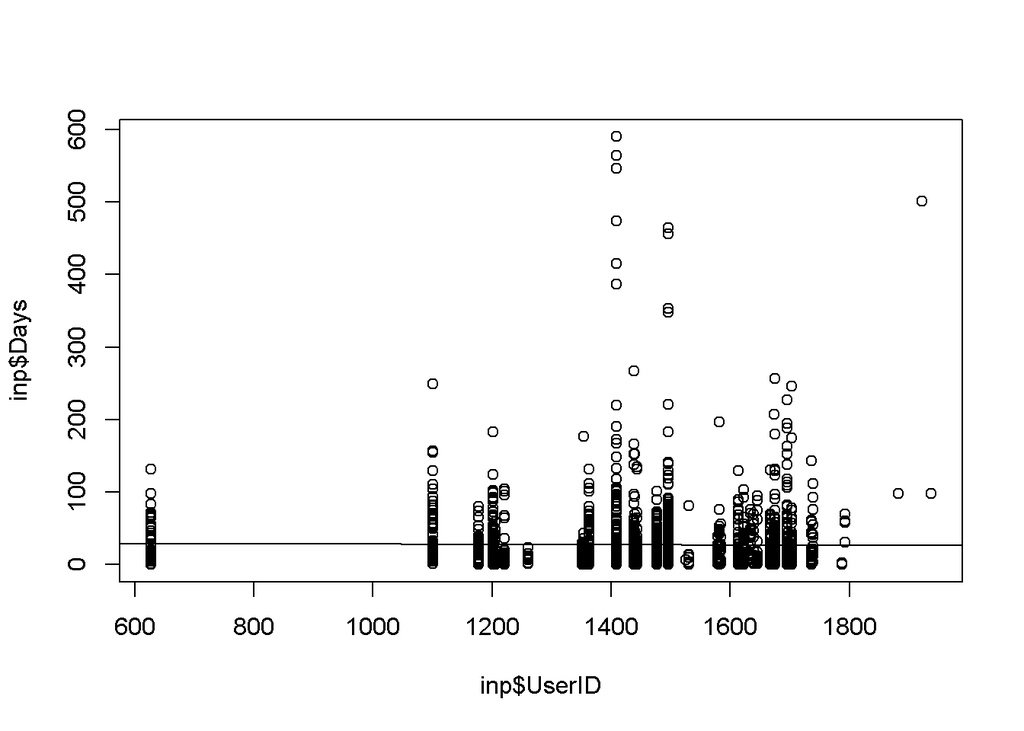

```r
plot(inp$Days ~ inp$UserID)
abline(fit4)
```

```r
fit5 <- lm(Days ~ SubjectId*UserID, data=inp)
summary(fit5)
```

```
##
## Call:
## lm(formula = Days ~ SubjectId * UserID, data = inp)
##
## Residuals:
##    Min     1Q Median     3Q    Max
## -51.66 -22.79 -14.98   0.81 564.19
##
## Coefficients:
##                    Estimate Std. Error t value Pr(>|t|)
## (Intercept)      -5.967e+02  7.798e+01  -7.652 2.22e-14 ***
## SubjectId         1.355e-02  1.678e-03   8.077 7.65e-16 ***
## UserID            4.266e-01  5.490e-02   7.771 8.78e-15 ***
## SubjectId:UserID -9.240e-06  1.179e-06  -7.836 5.26e-15 ***
## ---
## Signif. codes:  0 '***' 0.001 '**' 0.01 '*' 0.05 '.' 0.1 ' ' 1
##
## Residual standard error: 57.78 on 7787 degrees of freedom
## Multiple R-squared:  0.008821,   Adjusted R-squared:  0.008439
## F-statistic:  23.1 on 3 and 7787 DF,  p-value: 6.991e-15
```

## Model development

From the previous steps, we will only consider 2 independent variables for our model: *SiteId* and *FormId*

```r
model <- lm(Days ~ inp$SiteId.f + inp$FormId.f, data=inp)
summary(model)
```

```
##
## Call:
## lm(formula = Days ~ inp$SiteId.f + inp$FormId.f, data = inp)
##
## Residuals:
##    Min     1Q Median     3Q    Max
## -68.57 -23.51  -7.16   6.84 525.56
##
## Coefficients:
##                    Estimate Std. Error t value Pr(>|t|)
## (Intercept)          19.414      5.220   3.719 0.000201 ***
## inp$SiteId.f181       2.846      3.545   0.803 0.422021
## inp$SiteId.f200     -20.400      8.083  -2.524 0.011627 *
## inp$SiteId.f213     -16.390      3.972  -4.127 3.72e-05 ***
## inp$SiteId.f214      -7.892      3.705  -2.130 0.033179 *
## inp$SiteId.f218      16.172      3.560   4.543 5.63e-06 ***
## inp$SiteId.f232     -12.423      3.318  -3.744 0.000182 ***
## inp$SiteId.f233      -9.067      3.374  -2.687 0.007219 **
## inp$SiteId.f234     -11.290      4.373  -2.582 0.009852 **
## inp$SiteId.f235      24.866      3.414   7.283 3.60e-13 ***
## inp$SiteId.f237     -12.553      3.966  -3.166 0.001554 **
## inp$SiteId.f239      -9.446      5.700  -1.657 0.097497 .
## inp$SiteId.f240     -14.508      5.972  -2.429 0.015147 *
## inp$SiteId.f241     -19.075      6.055  -3.150 0.001638 **
## inp$SiteId.f322     -24.104      8.083  -2.982 0.002872 **
## inp$SiteId.f333     -11.838      3.871  -3.058 0.002235 **
## inp$FormId.f267627   26.127      6.409   4.077 4.61e-05 ***
## inp$FormId.f267628    9.195      5.677   1.620 0.105368
## inp$FormId.f267632    3.633      5.434   0.668 0.503880
## inp$FormId.f267634   34.988     11.540   3.032 0.002439 **
## inp$FormId.f267635   20.165      4.483   4.498 6.96e-06 ***
## inp$FormId.f267644    8.029      4.939   1.626 0.104087
## inp$FormId.f267646   -5.357      5.569  -0.962 0.336088
## inp$FormId.f267647   -2.431      6.253  -0.389 0.697495
## inp$FormId.f267654   -8.644      6.295  -1.373 0.169751
## inp$FormId.f267670   -2.279      5.144  -0.443 0.657784
## inp$FormId.f267671   -4.434      5.053  -0.877 0.380282
## inp$FormId.f267674   -5.354      5.447  -0.983 0.325627
## inp$FormId.f267678   -3.844      5.831  -0.659 0.509784
## inp$FormId.f267682    1.164      6.185   0.188 0.850736
## inp$FormId.f267683    2.027      5.451   0.372 0.709972
## ---
## Signif. codes:  0 '***' 0.001 '**' 0.01 '*' 0.05 '.' 0.1 ' ' 1
##
## Residual standard error: 55.39 on 7760 degrees of freedom
## Multiple R-squared:  0.09214,    Adjusted R-squared:  0.08863
## F-statistic: 26.25 on 30 and 7760 DF,  p-value: < 2.2e-16
```

## Model diagnostics

To assess whether the linear model is reliable, we need to check for (1) linearity, (2) nearly normal residuals, and (3) constant variability.

*Linearity*: We will verify this condition with a plot of the residuals vs. SiteID.

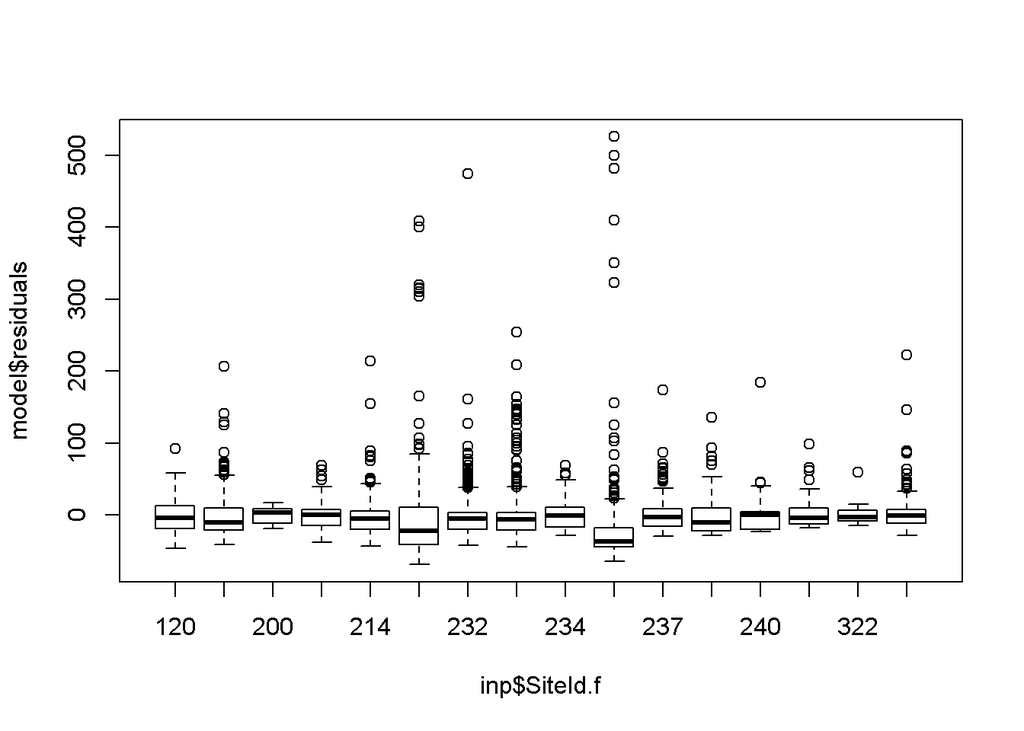

```r
plot(model$residuals ~ inp$SiteId.f + inp$FormId.f)
```

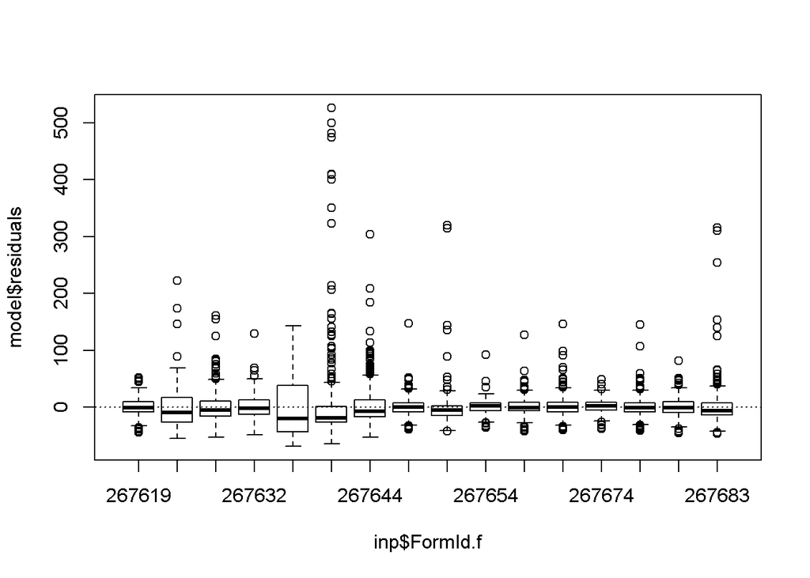

```r
abline(h = 0, lty = 3)  # adds a horizontal dashed line at y = 0
```

*Nearly normal residuals*: To check this condition, we can look at a histogram

```
## stat_bin: binwidth defaulted to range/30. Use 'binwidth = x' to adjust this.
```

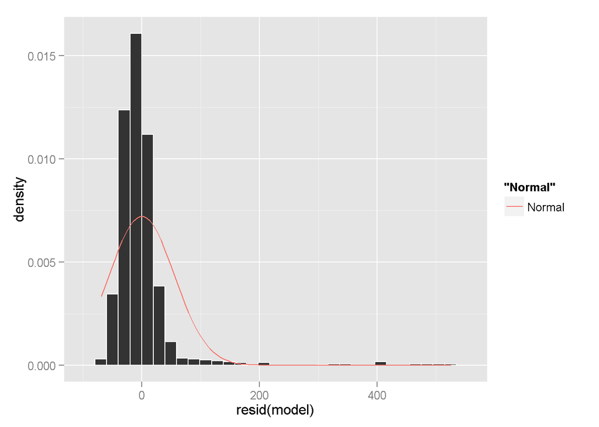

```r
#hist(model$residuals)
qplot(resid(model),geom="blank") +
geom_histogram( colour=I("white"), aes(y=..density..)) +
  stat_function(fun=dnorm, aes(colour="Normal"),arg=list(mean=mean(resid(model)),
                                                         sd=sd(resid(model))))
```

or a normal probability plot of the residuals.

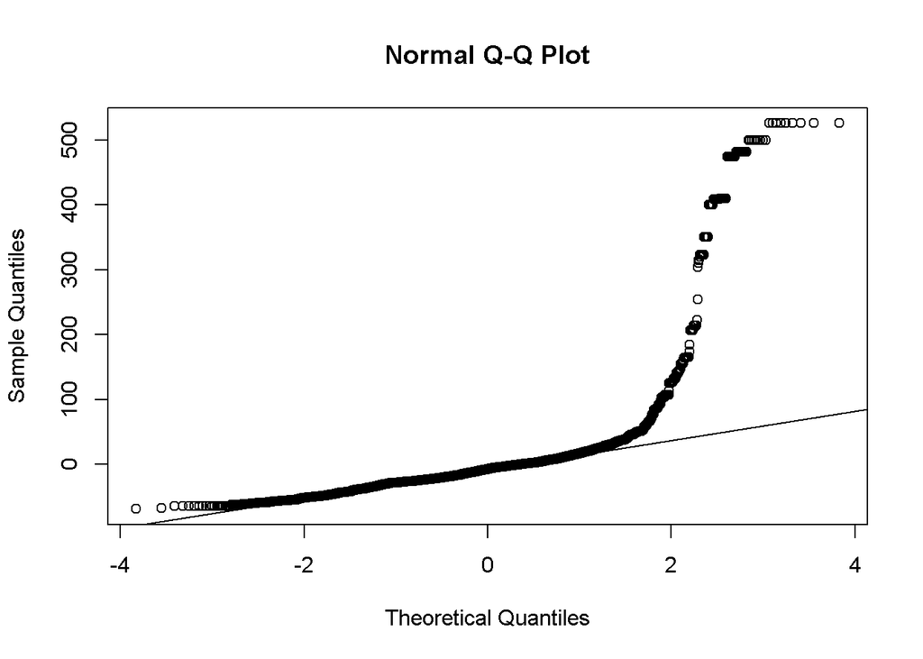

```r
qqnorm(model$residuals)
qqline(model$residuals)  # adds diagonal line to the normal prob plot
```

```r
library("car")
inp$Daysfitted <- fitted(model)
inp$Daysres <- residuals(model)
outlierTest(model)
```

```
##      rstudent unadjusted p-value Bonferonni p
## 7756 9.548399         1.7281e-21   1.3464e-17
## 7757 9.548399         1.7281e-21   1.3464e-17
## 7758 9.548399         1.7281e-21   1.3464e-17
## 7759 9.548399         1.7281e-21   1.3464e-17
## 7760 9.548399         1.7281e-21   1.3464e-17
## 7761 9.548399         1.7281e-21   1.3464e-17
## 7762 9.548399         1.7281e-21   1.3464e-17
## 7763 9.548399         1.7281e-21   1.3464e-17
## 7764 9.548399         1.7281e-21   1.3464e-17
## 7765 9.070884         1.4738e-19   1.1482e-15
```

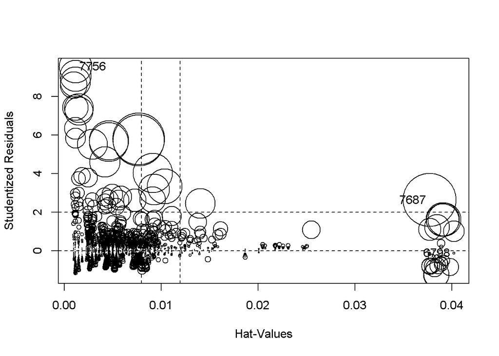

```
##         StudRes         Hat       CookD
## 6798 -0.1310583 0.040185433 0.004816725
## 7687  2.6264955 0.037685647 0.093316904
## 7756  9.5483988 0.001151604 0.057895230
```

```r
influencePlot(model)
```

```r
write.csv(file="predictedSiteDataEntry.csv", x=inp)
```

Although there are a number of outliers, only one of them appears to be influential. In the future, if we were to dig deeper into this particular model, we may want to consider the one influential outlier as it has a significant impact on the model.

Lets plot actuals vs predicted

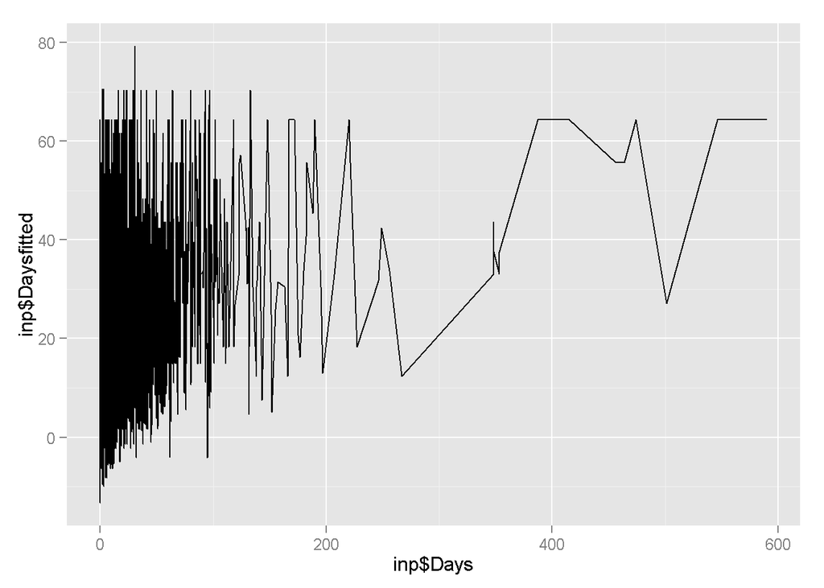

```r
qplot(inp$Days, inp$Daysfitted, geom="line")
```

### A3: Checking Homoscedasticity

To check homoscedasticity (i.e., homogeneity of variance), we use a scatter plot of residuals vs predicted y:

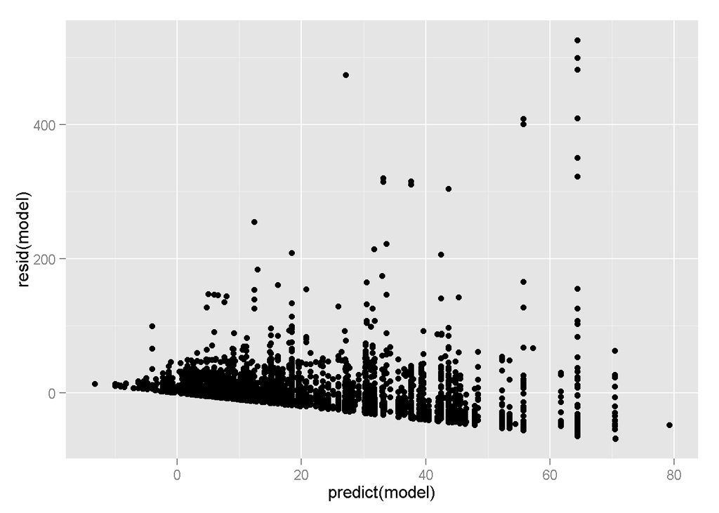

```r
qplot(predict(model),resid(model), geom="point")
```

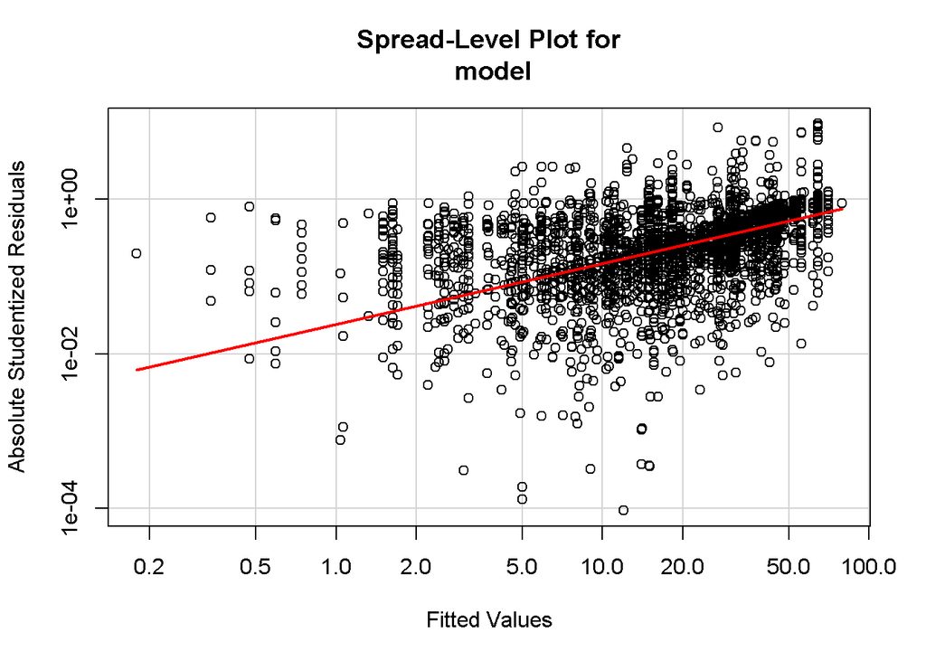

```
##
## Suggested power transformation:  0.2134286
```

```r
spreadLevelPlot(model) # we want the line to be horizontal
```

The line is not horizontal so our model does not pass this test either.

### A4: Checking Independence

Independence of errors. We use durbinWatsonTest and we want the statistic to be close to 2 and the p-value above alpha. We use the following test:

- H0 : errors are not correlated
- Ha : errors are dependent

```r
durbinWatsonTest(model)
```

```
##  lag Autocorrelation D-W Statistic p-value
##    1       0.9137754     0.1657162       0
##  Alternative hypothesis: rho != 0
```

CONCLUSION: As we can see, our Adjusted R-Squared value is 0.08863 which seems incredibly low. However, a better understanding of the industry and the ideal values within the industry would help us understand the true value of this number. As such, there seems to be a lot of noise in the data which is not allowing us to fit well all predictions of data entry considering only Site and Form (kind of data entered). Most importantly, the model does not pass all the model diagnostic steps indicating that this is not a goo model for the data. The possibility exists that a linear model is not the appropriate model to fit with this kind of data.